# Lab4_Spatial_ML_Part2

## Data Wrangling (from lab #1)

Start with cleaned and featurized data from previous lab

```r
#https://github.com/urbanSpatial/Public-Policy-Analytics-Landing/tree/master/DATA/Chapter3_4

## URL to data
data_src <- "https://raw.githubusercontent.com/urbanSpatial/Public-Policy-Analytics-Landing/master/DATA/Chapter3_4/"

nhoods <-
  st_read("http://bostonopendata-boston.opendata.arcgis.com/datasets/3525b0ee6e6b427f9aab5d0a1d0a1a28_0.geojson") %>%
  st_transform('ESRI:102286')

boston.sf   <- st_read(file.path(data_src,"boston_sf_Ch1_wrangled.geojson"))
```

```r
glimpse(boston.sf)
```

```
## Rows: 1,485
## Columns: 30
```

```
## $ Parcel_No      <int> 100032000, 100058000, 100073000, 100112000, 100137000,…
## $ SalePrice      <int> 450000, 600000, 450000, 670000, 260000, 355000, 665000…
## $ PricePerSq     <dbl> 228.89, 164.34, 105.98, 291.94, 217.21, 190.96, 227.35…
## $ LivingArea     <int> 1966, 3840, 4246, 2295, 1197, 1859, 2925, 2904, 892, 1…
## $ Style          <chr> "Conventional", "Semi?Det", "Decker", "Row End", "Colo…
## $ GROSS_AREA     <int> 3111, 5603, 6010, 3482, 1785, 2198, 4341, 3892, 1658, …
## $ NUM_FLOORS     <dbl> 2.0, 3.0, 3.0, 3.0, 2.0, 1.5, 3.0, 3.0, 2.0, 2.0, 1.5,…
## $ R_BDRMS        <int> 4, 8, 9, 6, 2, 3, 8, 6, 2, 2, 4, 3, 3, 3, 6, 8, 4, 4, …
## $ R_FULL_BTH     <int> 2, 3, 3, 3, 1, 3, 3, 3, 1, 2, 2, 3, 1, 1, 3, 3, 2, 3, …
## $ R_HALF_BTH     <int> 0, 0, 0, 0, 1, 0, 0, 0, 0, 0, 0, 0, 0, 1, 0, 0, 0, 1, …
## $ R_KITCH        <int> 2, 3, 3, 3, 1, 2, 3, 3, 1, 2, 2, 3, 1, 1, 3, 3, 2, 3, …
## $ R_AC           <chr> "N", "N", "N", "N", "N", "N", "N", "N", "N", "N", "N",…
## $ R_FPLACE       <int> 0, 0, 0, 0, 0, 0, 0, 0, 0, 0, 0, 0, 0, 0, 0, 0, 0, 0, …
## $ LU             <chr> "R2", "R3", "R3", "R3", "R1", "R2", "R3", "E", "R1", "…
## $ OWN_OCC        <chr> "Y", "N", "Y", "N", "N", "N", "N", "N", "N", "Y", "N",…
## $ R_BLDG_STY     <chr> "CV", "SD", "DK", "RE", "CL", "CV", "DK", "DK", "RE", …
## $ R_ROOF_TYP     <chr> "H", "F", "F", "F", "F", "G", "F", "F", "G", "F", "G",…
## $ R_EXT_FIN      <chr> "M", "B", "M", "M", "P", "M", "M", "A", "A", "M", "W",…
## $ R_TOTAL_RM     <int> 10, 17, 20, 14, 5, 8, 14, 14, 4, 9, 7, 7, 5, 5, 15, 14…
## $ R_HEAT_TYP     <chr> "W", "W", "W", "W", "E", "E", "W", "W", "W", "W", "W",…
## $ YR_BUILT       <int> 1900, 1910, 1910, 1905, 1860, 1905, 1900, 1890, 1900, …
## $ Name           <chr> "East Boston", "East Boston", "East Boston", "East Bos…
## $ crimes.Buffer  <dbl> 30, 28, 24, 23, 25, 25, 20, 19, 25, 26, 26, 19, 19, 21…
## $ crime_nn1      <dbl> 83.49594, 107.88455, 15.51440, 71.15965, 41.58905, 30.…
## $ crime_nn2      <dbl> 92.60684, 112.59782, 29.41763, 92.58565, 70.23179, 57.…
## $ crime_nn3      <dbl> 98.27133, 114.31439, 40.49954, 101.50927, 86.21772, 73…
## $ crime_nn4      <dbl> 118.29941, 116.06258, 56.43961, 106.35912, 100.38462, …
## $ crime_nn5      <dbl> 130.70252, 118.47266, 85.66739, 112.74718, 115.71793, …
## $ NUM_FLOORS.cat <chr> "Up to 2 Floors", "3 Floors", "3 Floors", "3 Floors", …
## $ geometry       <POINT [°]> POINT (238643.6 903342.3), POINT (238753.8 90324…
```

## Multivariate Linear Regression

repeating the same multivariate regression as last week. Regressing housing `SalePrice` on a variety of features from the Boston housing data.

```r
## Multivariate Regression
reg1 <- lm(SalePrice ~ ., data = st_drop_geometry(boston.sf) %>%
                                 dplyr::select(SalePrice, LivingArea,
                                               GROSS_AREA, R_TOTAL_RM, NUM_FLOORS,
                                               R_BDRMS, R_FULL_BTH, R_HALF_BTH,
                                               R_KITCH, R_FPLACE))
summary(reg1)
```

```
##
## Call:
## lm(formula = SalePrice ~ ., data = st_drop_geometry(boston.sf) %>%
##     dplyr::select(SalePrice, LivingArea, GROSS_AREA, R_TOTAL_RM,
##         NUM_FLOORS, R_BDRMS, R_FULL_BTH, R_HALF_BTH, R_KITCH,
##         R_FPLACE))
##
## Residuals:
##      Min       1Q   Median       3Q      Max
## -1637894  -191870   -13471   155906  7232733
##
## Coefficients:
##               Estimate Std. Error t value Pr(>|t|)
## (Intercept)   88112.35   49253.40   1.789 0.073826 .
## LivingArea      678.47      46.90  14.468  < 2e-16 ***
## GROSS_AREA     -269.12      27.93  -9.634  < 2e-16 ***
## R_TOTAL_RM   -32659.03    8603.99  -3.796 0.000153 ***
## NUM_FLOORS   161123.51   27482.42   5.863 5.61e-09 ***
## R_BDRMS      -40326.11   11746.51  -3.433 0.000613 ***
## R_FULL_BTH   245261.33   22502.50  10.899  < 2e-16 ***
## R_HALF_BTH    70399.49   22626.62   3.111 0.001898 **
## R_KITCH     -268289.02   30348.31  -8.840  < 2e-16 ***
## R_FPLACE     191206.51   16643.56  11.488  < 2e-16 ***
## ---
## Signif. codes:  0 '***' 0.001 '**' 0.01 '*' 0.05 '.' 0.1 ' ' 1
##
## Residual standard error: 424100 on 1475 degrees of freedom
## Multiple R-squared:  0.5111, Adjusted R-squared:  0.5081
## F-statistic: 171.3 on 9 and 1475 DF,  p-value: < 2.2e-16
```

### Internal model stats

From last week we learned about metrics that the `lm()` function fits internally on the data used in training. Here is a rather complete view of those metrics using the `broom` package.

```r
# paste0("Adjust R-Squared: ", round(summary(reg1)$adj.r.squared,2))
broom::glance(reg1)
```

```
## # A tibble: 1 x 12
##   r.squared adj.r.squared  sigma statistic   p.value    df  logLik    AIC    BIC
##       <dbl>         <dbl>  <dbl>     <dbl>     <dbl> <dbl>   <dbl>  <dbl>  <dbl>
## 1     0.511         0.508 4.24e5      171. 6.08e-222     9 -21344. 42711. 42769.
## # … with 3 more variables: deviance <dbl>, df.residual <int>, nobs <int>
```

#### Questions:

##### What does Adjusted R-squared tell us about this model?

> How many variances can be explained by the model.

##### What issues may exist with judging the accuracy of a model based solely on the data used to fit the model?

## External model validation

Evaluating a model through its predictions on *new* data.

```r
# set random seed
set.seed(31357)

# get index for training sample
inTrain <- caret::createDataPartition(
              y = boston.sf$SalePrice,
              p = .60, list = FALSE)
# split data into training and test
boston.training <- boston.sf[inTrain,]
boston.test     <- boston.sf[-inTrain,]

# Regression
reg2 <- lm(SalePrice ~ ., data = st_drop_geometry(boston.training) %>%
                                 dplyr::select(SalePrice, LivingArea,
                                               GROSS_AREA, R_TOTAL_RM, NUM_FLOORS,
                                               R_BDRMS, R_FULL_BTH, R_HALF_BTH,
                                               R_KITCH, R_FPLACE))

# Run this a number of times to see Adjusted R2
summary(reg2)
```

```
##
## Call:
## lm(formula = SalePrice ~ ., data = st_drop_geometry(boston.training) %>%
##     dplyr::select(SalePrice, LivingArea, GROSS_AREA, R_TOTAL_RM,
##         NUM_FLOORS, R_BDRMS, R_FULL_BTH, R_HALF_BTH, R_KITCH,
##         R_FPLACE))
##
## Residuals:
##      Min       1Q   Median       3Q      Max
## -1659975  -198772    -7119   176926  7013405
##
## Coefficients:
##               Estimate Std. Error t value Pr(>|t|)
## (Intercept)  144837.96   71430.52   2.028  0.04289 *
## LivingArea      903.51      67.72  13.343  < 2e-16 ***
## GROSS_AREA     -390.26      41.57  -9.387  < 2e-16 ***
## R_TOTAL_RM   -32329.21   11532.20  -2.803  0.00517 **
## NUM_FLOORS   105847.20   38557.94   2.745  0.00617 **
## R_BDRMS      -47999.04   16332.45  -2.939  0.00338 **
## R_FULL_BTH   268915.72   33364.94   8.060 2.47e-15 ***
## R_HALF_BTH    98948.95   31320.35   3.159  0.00164 **
## R_KITCH     -285497.04   43540.73  -6.557 9.33e-11 ***
## R_FPLACE     183117.99   24211.06   7.563 9.85e-14 ***
## ---
## Signif. codes:  0 '***' 0.001 '**' 0.01 '*' 0.05 '.' 0.1 ' ' 1
##
## Residual standard error: 463100 on 883 degrees of freedom
## Multiple R-squared:  0.5322, Adjusted R-squared:  0.5274
## F-statistic: 111.6 on 9 and 883 DF,  p-value: < 2.2e-16
```

```r
## predicting on new data
reg2_predict <- predict(reg2, newdata = boston.test)
```

## Measure generalizability?

> How do we measure a model’s ability to predict to new data?

```r
## Mean Square Error train and test
rmse.train <- caret::MAE(predict(reg2), boston.training$SalePrice)
rmse.test  <- caret::MAE(reg2_predict, boston.test$SalePrice)
```

```r
cat("Train MAE: ", as.integer(rmse.train), " \n","Test MAE: ", as.integer(rmse.test))
```

```
## Train MAE:  264505
##  Test MAE:  265863
```

Common regression metrics that compute a single number from the difference between what is predicted and the actual values.

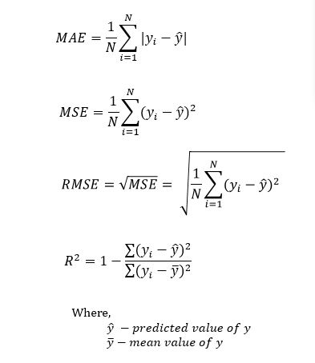

image [from here](https://www.datatechnotes.com/2019/02/regression-model-accuracy-mae-mse-rmse.html)

## Plotting accuracy metrics

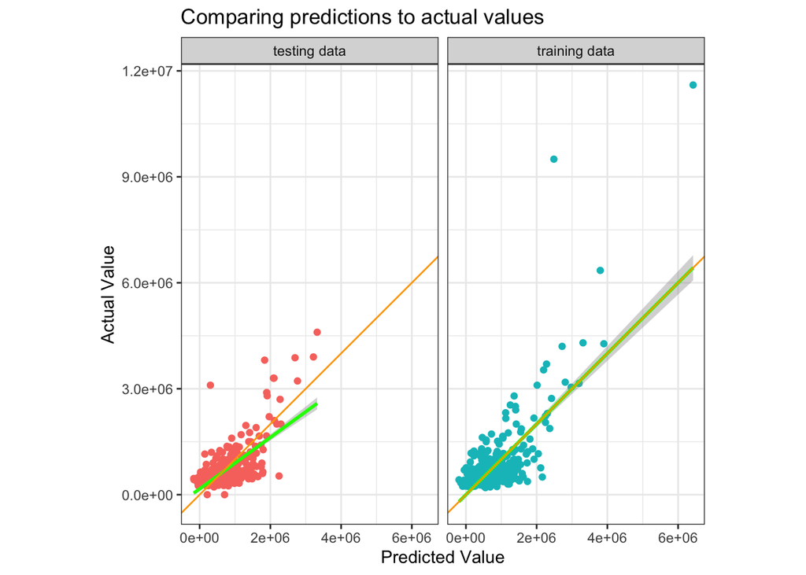

```r
preds.train <- data.frame(pred   = predict(reg2),
                          actual = boston.training$SalePrice,
                          source = "training data")
preds.test  <- data.frame(pred   = reg2_predict,
                          actual = boston.test$SalePrice,
                          source = "testing data")
preds <- rbind(preds.train, preds.test)

ggplot(preds, aes(x = pred, y = actual, color = source)) +
  geom_point() +
  geom_smooth(method = "lm", color = "green") +
  geom_abline(color = "orange") +
  coord_equal() +
  theme_bw() +
  facet_wrap(~source, ncol = 2) +
  labs(title = "Comparing predictions to actual values",
       x = "Predicted Value",
       y = "Actual Value") +
  theme(
    legend.position = "none"
  )
```

> What insight can we gain from this plot?

> Is there any danger in using a single random split for training/testing data?

## Cross-validation

In theory, **Cross**-*validation* is a technique for assessing how the results of a model generalize to an independent sample. *Cross*-*validation* is largely used in settings where the target is prediction and it is necessary to estimate the accuracy of the performance of a predictive model.

In practice, **Cross**-*validation* is a method to split a data set into a number (referred to as *k*) samples and the use all but one sample (*k* - 1) for training and the remaining sample for testing. This is done *k* times where each sample gets a turn to be the test set. Specifically, this is referred to as **k-folds Cross-Validation**. See the image below from the book as an illustration.

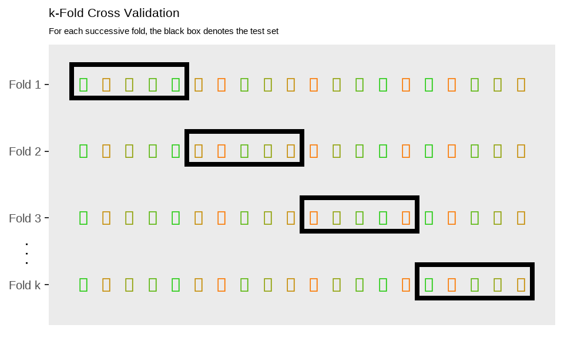

> What is the benefits of using multiple test train splits this way?

> Are there other options for how data can be split?

```r
# use caret package cross-validation method
fitControl <- trainControl(method = "cv",
                           number = 10,
                           # savePredictions differs from book
                           savePredictions = TRUE)

set.seed(717)
# crimes.buffer feature added
# for k-folds CV
reg.cv <-
  train(SalePrice ~ ., data = st_drop_geometry(boston.sf) %>%
                                dplyr::select(SalePrice, LivingArea,
                                               GROSS_AREA, R_TOTAL_RM, NUM_FLOORS,
                                               R_BDRMS, R_FULL_BTH, R_HALF_BTH,
                                               R_KITCH, R_FPLACE, crimes.Buffer),
     method = "lm",
     trControl = fitControl,
     na.action = na.pass)

reg.cv
```

```
## Linear Regression
##
## 1485 samples
##   10 predictor
##
## No pre-processing
## Resampling: Cross-Validated (10 fold)
## Summary of sample sizes: 1337, 1337, 1336, 1335, 1337, 1337, ...
## Resampling results:
##
##   RMSE      Rsquared   MAE
##   415241.3  0.5152416  245269.7
##
## Tuning parameter 'intercept' was held constant at a value of TRUE
```

```r
reg.cv$resample
```

```
##        RMSE  Rsquared      MAE Resample
## 1  675941.7 0.2945504 276416.7   Fold01
## 2  369841.9 0.3410855 250108.0   Fold02
## 3  368167.9 0.5866561 246425.4   Fold03
## 4  380621.9 0.3786402 240403.3   Fold04
## 5  305656.3 0.6074219 229799.8   Fold05
## 6  335957.9 0.3715664 241791.9   Fold06
## 7  627726.9 0.7405234 250344.2   Fold07
## 8  354013.4 0.6453627 239917.3   Fold08
## 9  404586.6 0.5956115 247275.3   Fold09
## 10 329898.6 0.5909977 230215.4   Fold10
```

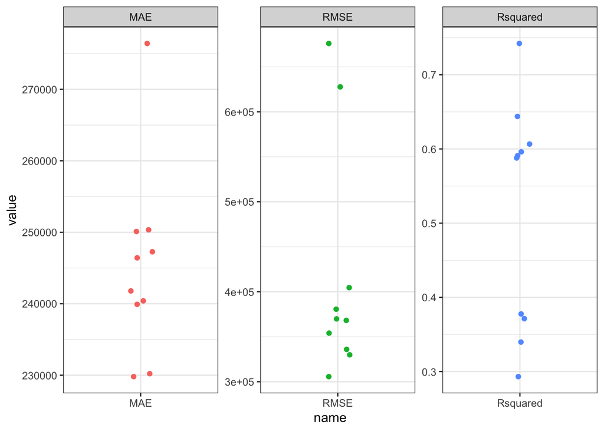

```r
reg.cv$resample %>%
  pivot_longer(-Resample) %>%
  mutate(name = as.factor(name)) %>%
  ggplot(., aes(x = name, y = value, color = name)) +
  geom_jitter(width = 0.1) +
  facet_wrap(~name, ncol = 3, scales = "free") +
  theme_bw() +
  theme(
    legend.position = "none"
  )
```

> How do we interpret the spread of values between the folds?

```r
# extract predictions from CV object
cv_preds <- reg.cv$pred
# compare number of observations between data sets
nrow(boston.sf)
```

```
## [1] 1485
```

```r
nrow(cv_preds)
```

```
## [1] 1485
```

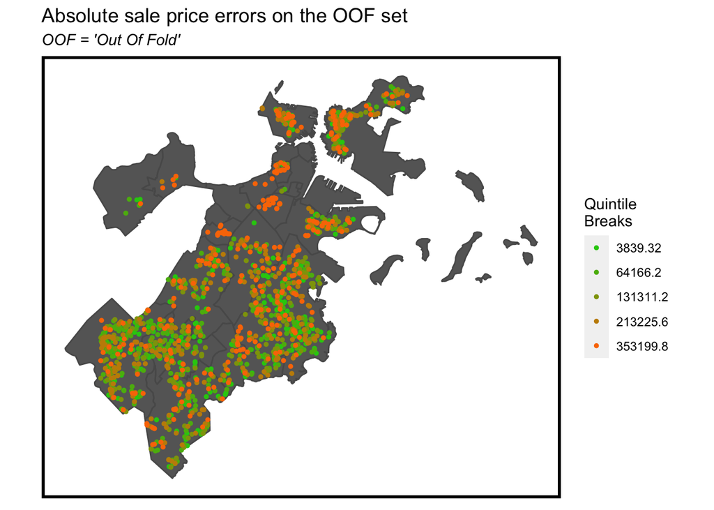

```r
## Create dataset with "out of fold" predictions and original data
map_preds <- boston.sf %>%
  rowid_to_column(var = "rowIndex") %>%
  left_join(cv_preds, by = "rowIndex") %>%
  mutate(SalePrice.AbsError = abs(pred - SalePrice)) %>%
  cbind(st_coordinates(.))
# weird CRS fix to boston.sf
st_crs(map_preds) <- st_crs(nhoods)
# plot errors on a map
ggplot() +
    geom_sf(data = nhoods, fill = "grey40") +
    geom_sf(data = map_preds, aes(colour = q5(SalePrice.AbsError)),
            show.legend = "point", size = 1) +
    scale_colour_manual(values = palette5,
                     labels=qBr(map_preds,"SalePrice.AbsError"),
                     name="Quintile\nBreaks") +
    labs(title="Absolute sale price errors on the OOF set",
         subtitle = "OOF = 'Out Of Fold'") +
    mapTheme()
```

> Is there a spatial pattern in these errors?

## Spatial Correlation of Errors

Going back to single random data split to align with book

```r
inTrain <- createDataPartition(
              y = paste(boston.sf$Name, boston.sf$NUM_FLOORS.cat,
                        boston.sf$Style, boston.sf$R_AC),
              p = .60, list = FALSE)
boston.training <- boston.sf[inTrain,]
boston.test <- boston.sf[-inTrain,]

reg.training <-
  lm(SalePrice ~ ., data = as.data.frame(boston.training) %>%
                             dplyr::select(SalePrice, LivingArea, Style,
                                           GROSS_AREA, NUM_FLOORS.cat,
                                           R_BDRMS, R_FULL_BTH, R_HALF_BTH,
                                           R_KITCH, R_AC, R_FPLACE, crimes.Buffer))

boston.test <-
  boston.test %>%
  mutate(Regression = "Baseline Regression",
         SalePrice.Predict = predict(reg.training, boston.test),
         SalePrice.Error = SalePrice.Predict - SalePrice,
         SalePrice.AbsError = abs(SalePrice.Predict - SalePrice),
         SalePrice.APE = (abs(SalePrice.Predict - SalePrice)) / SalePrice.Predict)%>%
  filter(SalePrice < 5000000)
```

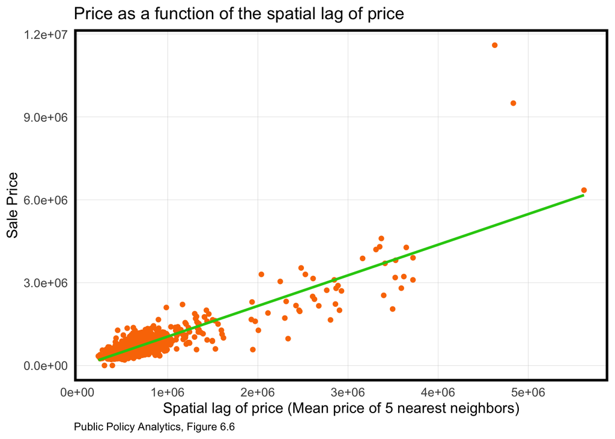

```r
k_nearest_neighbors = 5
#prices
coords <- st_coordinates(boston.sf)
# k nearest neighbors
neighborList <- knn2nb(knearneigh(coords, k_nearest_neighbors))
spatialWeights <- nb2listw(neighborList, style="W")
boston.sf$lagPrice <- lag.listw(spatialWeights, boston.sf$SalePrice)

#errors
coords.test <-  st_coordinates(boston.test)
neighborList.test <- knn2nb(knearneigh(coords.test, k_nearest_neighbors))
spatialWeights.test <- nb2listw(neighborList.test, style="W")
boston.test$lagPriceError <- lag.listw(spatialWeights.test, boston.test$SalePrice.AbsError)

ggplot(boston.sf, aes(x=lagPrice, y=SalePrice)) +
   geom_point(colour = "#FA7800") +
   geom_smooth(method = "lm", se = FALSE, colour = "#25CB10") +
   labs(title = "Price as a function of the spatial lag of price",
        caption = "Public Policy Analytics, Figure 6.6",
        x = "Spatial lag of price (Mean price of 5 nearest neighbors)",
        y = "Sale Price") +
   plotTheme()
```

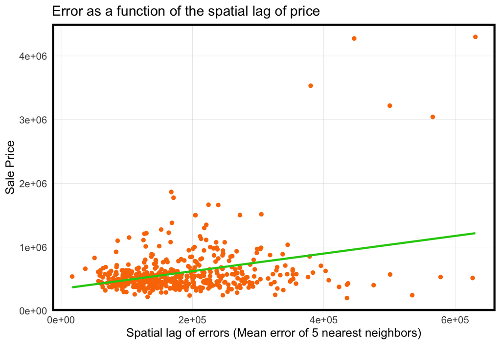

```r
ggplot(boston.test, aes(x=lagPriceError, y=SalePrice)) +
    geom_point(colour = "#FA7800") +
    geom_smooth(method = "lm", se = FALSE, colour = "#25CB10") +
    labs(title = "Error as a function of the spatial lag of price",
         caption = "",
         x = "Spatial lag of errors (Mean error of 5 nearest neighbors)",
         y = "Sale Price") +
    plotTheme()
```

> Are sale prices and errors in predicting sales prices correlated across space?

## Moran’s I - A measure of spatial correlation

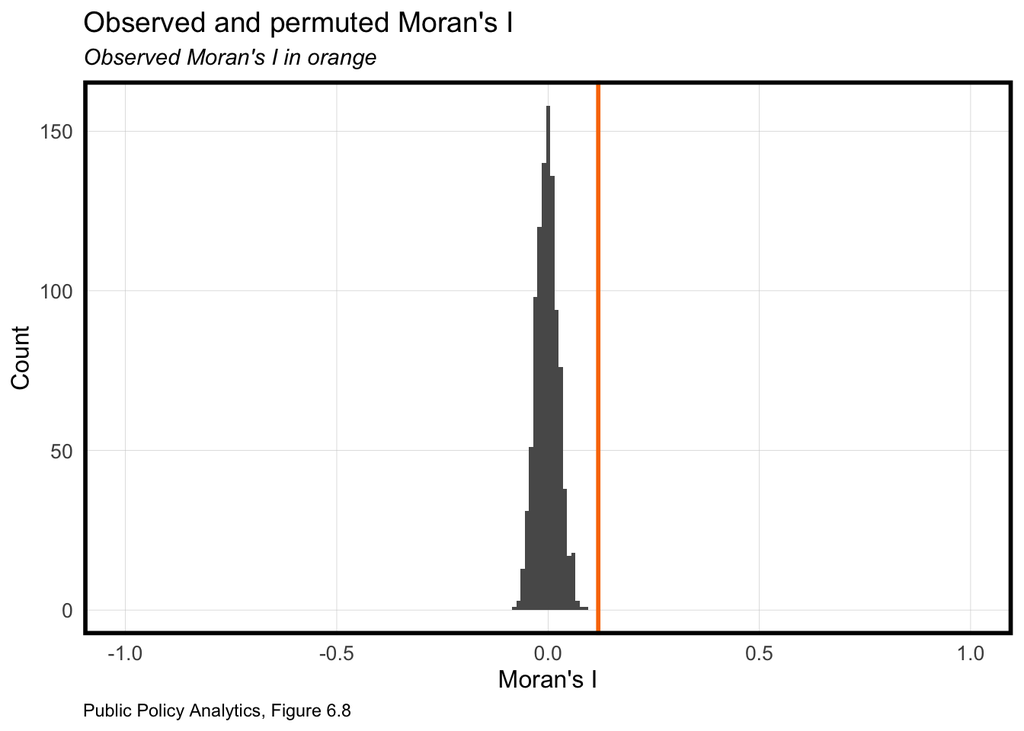

```r
moranTest <- moran.mc(boston.test$SalePrice.AbsError,
                      spatialWeights.test, nsim = 999)

ggplot(as.data.frame(moranTest$res[c(1:999)]), aes(moranTest$res[c(1:999)])) +
  geom_histogram(binwidth = 0.01) +
  geom_vline(aes(xintercept = moranTest$statistic), colour = "#FA7800",size=1) +
  scale_x_continuous(limits = c(-1, 1)) +
  labs(title="Observed and permuted Moran's I",
       subtitle= "Observed Moran's I in orange",
       x="Moran's I",
       y="Count",
       caption="Public Policy Analytics, Figure 6.8") +
  plotTheme()
```

> What does a positive Moran’s I tell us?

## Errors by group

```r
nhood_sum <- boston.test %>%
    group_by(Name) %>%
    summarize(meanPrice = mean(SalePrice, na.rm = T),
              meanPrediction = mean(SalePrice.Predict, na.rm = T),
              meanMAE = mean(SalePrice.AbsError, na.rm = T))

nhood_sum %>%
  st_drop_geometry %>%
  arrange(desc(meanMAE)) %>%
      kable() %>% kable_styling()
```

| Name | meanPrice | meanPrediction | meanMAE |
| --- | --- | --- | --- |
| Mission Hill | 1507500.0 | 732602.2 | 774897.8 |
| South End | 3524000.0 | 3316615.3 | 607224.6 |
| Beacon Hill | 2969750.0 | 3381044.0 | 411294.0 |
| Roxbury | 478409.5 | 601036.9 | 242372.5 |
| South Boston | 669721.9 | 559861.4 | 238262.4 |
| East Boston | 513582.1 | 616384.3 | 214964.6 |
| Charlestown | 1053323.1 | 1085676.8 | 208051.5 |
| Jamaica Plain | 878978.9 | 775454.7 | 188993.5 |
| Dorchester | 532286.6 | 570389.7 | 185845.2 |
| Mattapan | 417784.2 | 565419.9 | 176155.7 |
| Roslindale | 498914.3 | 485045.7 | 143190.6 |
| Hyde Park | 402874.1 | 487719.4 | 140880.1 |
| West Roxbury | 551061.4 | 584212.8 | 129724.6 |

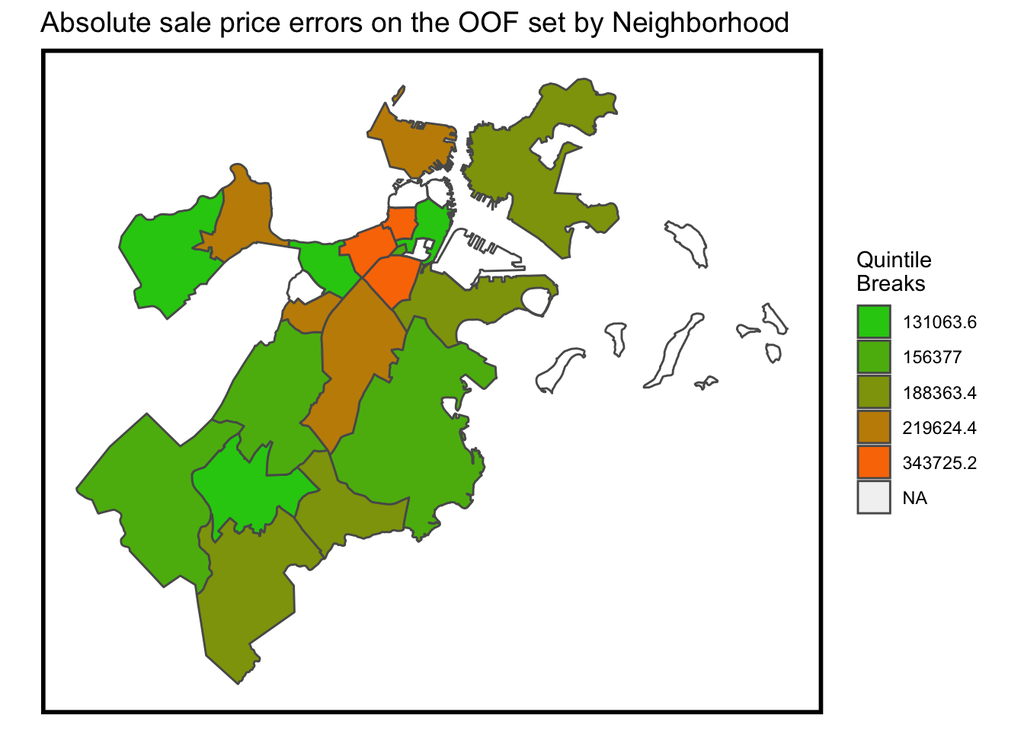

```r
## Back to CV predictions for the moment. In the split sample predictions we only get predictions for the nhoods in the test sample; the rest are NA. In the CV split, we get a prediction on each nhood. That makes for a more complete looking map.

  map_preds_sum <- map_preds %>%
    group_by(Name) %>%
    summarise(meanMAE = mean(SalePrice.AbsError))
  ggplot() +
    geom_sf(data = nhoods %>%
              left_join(st_drop_geometry(map_preds_sum), by = "Name"),
            aes(fill = q5(meanMAE))) +
      scale_fill_manual(values = palette5,
                     labels=qBr(nhood_sum,"meanMAE"),
                     name="Quintile\nBreaks") +
    mapTheme() +
    labs(title="Absolute sale price errors on the OOF set by Neighborhood")
```

> Do you see a spatial pattern in Neighborhood errors?

## Controlling for Neighborhood

> How might we control for the effect that being in a specific neighborhood has on a sales price?

```r
## Neighborhood Fixed Effect
reg.nhood <- lm(SalePrice ~ ., data = as.data.frame(boston.training) %>%
                                 dplyr::select(Name, SalePrice, LivingArea,
                                               Style, GROSS_AREA, NUM_FLOORS.cat,
                                               R_BDRMS, R_FULL_BTH, R_HALF_BTH,
                                               R_KITCH, R_AC, R_FPLACE,crimes.Buffer))

boston.test.nhood <-
  boston.test %>%
  mutate(Regression = "Neighborhood Effects",
         SalePrice.Predict = predict(reg.nhood, boston.test),
         SalePrice.Error = SalePrice - SalePrice.Predict,
         SalePrice.AbsError = abs(SalePrice - SalePrice.Predict),
         SalePrice.APE = (abs(SalePrice - SalePrice.Predict)) / SalePrice) %>%
  filter(SalePrice < 5000000)
```

```r
bothRegressions <-
  rbind(
    dplyr::select(boston.test, starts_with("SalePrice"), Regression, Name) %>%
      mutate(lagPriceError = lag.listw(spatialWeights.test, SalePrice.Error)),
    dplyr::select(boston.test.nhood, starts_with("SalePrice"), Regression, Name) %>%
      mutate(lagPriceError = lag.listw(spatialWeights.test, SalePrice.Error)))

st_drop_geometry(bothRegressions) %>%
  gather(Variable, Value, -Regression, -Name) %>%
  filter(Variable == "SalePrice.AbsError" | Variable == "SalePrice.APE") %>%
  group_by(Regression, Variable) %>%
    summarize(meanValue = mean(Value, na.rm = T)) %>%
    spread(Variable, meanValue) %>%
    kable() %>%
      kable_styling("striped", full_width = F) %>%
      row_spec(1, color = "black", background = "#25CB10") %>%
      row_spec(2, color = "black", background = "#FA7800")
```

| Regression | SalePrice.AbsError | SalePrice.APE |
| --- | --- | --- |
| Baseline Regression | 182490.7 | 0.4611091 |
| Neighborhood Effects | 108263.7 | 0.1930149 |

### The key question to be able to answer from this is:

> Which model better captures the spatial process of home sales prices and why?

Here is a good bit of the answer:

```r
# model coefficents for each Neighborhood
tidy(reg.nhood) %>%
  filter(str_detect(term, "Name")) %>%
  kable() %>%
  kable_styling()
```

| term | estimate | std.error | statistic | p.value |
| --- | --- | --- | --- | --- |
| NameBack Bay | 6829259.90 | 154300.52 | 44.2594736 | 0.0000000 |
| NameBay Village | 1163902.87 | 216811.12 | 5.3682804 | 0.0000001 |
| NameBeacon Hill | 1392072.31 | 104894.61 | 13.2711523 | 0.0000000 |
| NameBrighton | -163905.32 | 113419.66 | -1.4451227 | 0.1487549 |
| NameCharlestown | -19791.77 | 90588.02 | -0.2184811 | 0.8271015 |
| NameDorchester | -417210.83 | 84327.69 | -4.9474952 | 0.0000009 |
| NameDowntown | 141959.41 | 216264.69 | 0.6564151 | 0.5117169 |
| NameEast Boston | -408860.71 | 86375.64 | -4.7335188 | 0.0000025 |
| NameFenway | 824147.20 | 165303.11 | 4.9856726 | 0.0000007 |
| NameHyde Park | -497437.54 | 85583.31 | -5.8123197 | 0.0000000 |
| NameJamaica Plain | -155329.11 | 86029.47 | -1.8055338 | 0.0713093 |
| NameMattapan | -460980.88 | 88442.50 | -5.2122102 | 0.0000002 |
| NameMission Hill | 293246.52 | 98572.45 | 2.9749340 | 0.0030051 |
| NameRoslindale | -398888.45 | 85930.38 | -4.6419958 | 0.0000039 |
| NameRoxbury | -344594.74 | 90085.22 | -3.8252084 | 0.0001392 |
| NameSouth Boston | -56617.04 | 89046.12 | -0.6358170 | 0.5250496 |
| NameSouth End | 1422810.39 | 102710.50 | 13.8526279 | 0.0000000 |
| NameWest Roxbury | -379179.79 | 85702.21 | -4.4243877 | 0.0000108 |